# Currency trading tweet explorer

Github: github.com/simw/twitter-tagger

I set up an AWS machine with mongo and tweepy, filtered the twitter stream on some keywords and saved the resulting tweets to mongo.

### Retrieving data from AWS

I could (try and) run IPython hosted on the AWS machine, or open up a port (and password) for remote access to mongo ... but really, it's easier here to just do mongodump there, rsync from there to here, and mongorestore here.

```python
%%bash
# On remote machine: mongodump --db ver1 (as the db / collection is called 'ver1')
DNS=`aws ec2 describe-instances --instance-ids i-26c1b22a --query 'Reservations[].Instances[].PublicDnsName' --output text`
echo "Connecting to $DNS"
rsync -rave "ssh -i /home/simon/.ssh/AmazonBasic-August2014.pem" ubuntu@$DNS:~/dump .
mongorestore dump
```

```
Connecting to ec2-54-148-47-96.us-west-2.compute.amazonaws.com
receiving incremental file list
dump/ver1/alltweets.bson
dump/ver1/alltweets.metadata.json
dump/ver1/keywords.bson
dump/ver1/keywords.metadata.json
dump/ver1/system.indexes.bson
dump/ver1/taggedtweets.bson
dump/ver1/taggedtweets.metadata.json

sent 190,754 bytes  received 248,640,162 bytes  5,591,705.98 bytes/sec
total size is 695,315,819  speedup is 2.79
connected to: 127.0.0.1
2015-02-17T08:49:23.325-0800 dump/ver1/alltweets.bson
2015-02-17T08:49:23.325-0800 	going into namespace [ver1.alltweets]
2015-02-17T08:49:26.013-0800 		Progress: 90108852/610819064	14%	(bytes)
2015-02-17T08:49:29.042-0800 		Progress: 181447821/610819064	29%	(bytes)
2015-02-17T08:49:32.027-0800 		Progress: 271244760/610819064	44%	(bytes)
2015-02-17T08:49:35.031-0800 		Progress: 358152767/610819064	58%	(bytes)
2015-02-17T08:49:38.065-0800 		Progress: 476262858/610819064	77%	(bytes)
255647 objects found
2015-02-17T08:49:40.759-0800 	Creating index: { key: { _id: 1 }, ns: "ver1.alltweets", name: "_id_" }
2015-02-17T08:49:41.074-0800 dump/ver1/taggedtweets.bson
2015-02-17T08:49:41.074-0800 	going into namespace [ver1.taggedtweets]
2015-02-17T08:49:44.080-0800 		Progress: 24316360/84495076	28%	(bytes)
2015-02-17T08:49:47.308-0800 		Progress: 39337220/84495076	46%	(bytes)
2015-02-17T08:49:50.295-0800 		Progress: 52575838/84495076	62%	(bytes)
2015-02-17T08:49:53.142-0800 		Progress: 66034753/84495076	78%	(bytes)
247438 objects found
2015-02-17T08:49:54.772-0800 	Creating index: { key: { _id: 1 }, ns: "ver1.taggedtweets", name: "_id_" }
2015-02-17T08:49:55.665-0800 dump/ver1/keywords.bson
2015-02-17T08:49:55.665-0800 	going into namespace [ver1.keywords]
20 objects found
2015-02-17T08:49:55.665-0800 	Creating index: { key: { _id: 1 }, ns: "ver1.keywords", name: "_id_" }
```

```
Restoring to ver1.alltweets without dropping. Restored data will be inserted without raising errors; check your server log
Restoring to ver1.taggedtweets without dropping. Restored data will be inserted without raising errors; check your server log
Restoring to ver1.keywords without dropping. Restored data will be inserted without raising errors; check your server log
```

Now we can check and analyse the data locally

```python
from __future__ import print_function
from __future__ import unicode_literals
from __future__ import division

from IPython.core.display import display

from pymongo import MongoClient
connection = MongoClient()
db = connection.ver1
```

Here are the keywords on which we were filtering the twitter stream. These are various versions of the exchange rates

- EurUsd (Euro-Dollar),
- GbpUsd (pounds sterling vs the dollar, aka 'cable')
- UsdJpy (Dollar-Yen - ie Japanese Yen) and
- UsdMxn (Dollar-Mex - ie mexican peso)

```python
print('Keywords used for stream.filter():')
print([word['keyword'] for word in list(db.keywords.find(None, {'keyword': 1, '_id': 0}))])
```

```
Keywords used for stream.filter():
[u'eurusd', u'eur/usd', u'$eur/usd', u'$eurusd', u'#eurusd', u'gbpusd', u'gbp/usd', u'$gbp/usd', u'$gbpusd', u'#gbpusd', u'usdjpy', u'usd/jpy', u'$usd/jpy', u'$usdjpy', u'#usdjpy', u'usdmxn', u'usd/mxn', u'$usd/mxn', u'$usdmxn', u'#usdmxn']
```

### Importing the tweets into IPython & pandas

I didn't save all the tweet info from twitter, just some relevant fields. We're looking at ~1 week of tweets.

```python
tweets = list(db.taggedtweets.find())
print('Number of tweets = {}'.format(len(tweets)))
print('')
print('Tweet information: {}'.format(tweets[0].keys()))
print('')
print('Example:')
print(tweets[0])
```

```
Number of tweets = 247438

Tweet information: [u'lang', u'user_followers', u'text', u'created_at', u'twitter_id', u'coordinates', u'in_reply_to_status_id', u'user_friends', u'user', u'keywords', u'_id']

Example:
{u'lang': u'en', u'user_followers': 17706, u'text': u'The $EURUSD market will possibly go much lower, and test at least the 1.10 level. http://t.co/yyrTTLmXi2 #Euro #Fx http://t.co/iFbq1DAm9N', u'created_at': u'Mon Feb 09 19:09:52 +0000 2015', u'twitter_id': 564863773765148672L, u'coordinates': None…
```

```python
import pandas as pd
import numpy as np
import math
import matplotlib.pyplot as plt
%matplotlib inline
```

Note, the dates *should be* in UTC, gotta love that Greenwich Mean Time.

```python
data = pd.DataFrame(tweets)
data['created_at'] = pd.to_datetime(data['created_at'])
```

```python
display(data.head(1))
print('')
print('Column types:')
display(data.dtypes)
```

|  | _id | coordinates | created_at | in_reply_to_status_id | keywords | lang | text | twitter_id | user | user_followers | user_friends |
| --- | --- | --- | --- | --- | --- | --- | --- | --- | --- | --- | --- |
| 0 | 54d90601d891e41645eff0cf | None | 2015-02-09 19:09:52 | NaN | [eurusd] | en | The $EURUSD market will possibly go much lower... | 564863773765148672 | Daily_Forex | 17706 | 2528 |

```
Column types:
```

```
_id                              object
coordinates                      object
created_at               datetime64[ns]
in_reply_to_status_id           float64
keywords                         object
lang                             object
text                             object
twitter_id                        int64
user                             object
user_followers                    int64
user_friends                      int64
dtype: object
```

```python
print('{:%A %Y-%m-%d %H:%M:%S}'.format(data['created_at'].min()))
print('{:%A %Y-%m-%d %H:%M:%S}'.format(data['created_at'].max()))
```

```
Monday 2015-02-09 19:09:52
Tuesday 2015-02-17 16:47:25
```

## Some basic analysis of our tweets

### Day and time distribution

OK, so my tweet-collector crashed at some point (looks like Tuesday afternoon), plus I didn't monitor the stream or error messages from twitter, so this isn't rigorous ...

```python
from matplotlib.dates import date2num, num2date
```

```python
start_day_as_num = int(date2num(data['created_at'].min()))
dts = np.array([date2num(d) - start_day_as_num for d in data['created_at']])
```

```python
from matplotlib import rcParams
rcParams['axes.titlesize'] = 16
rcParams['axes.labelsize'] = 14
rcParams['xtick.labelsize'] = 14
rcParams['ytick.labelsize'] = 14
rcParams['legend.fontsize'] = 14

rcParams['font.family'] = 'serif'
rcParams['font.serif'] = ['Bitstream Vera Serif']
```

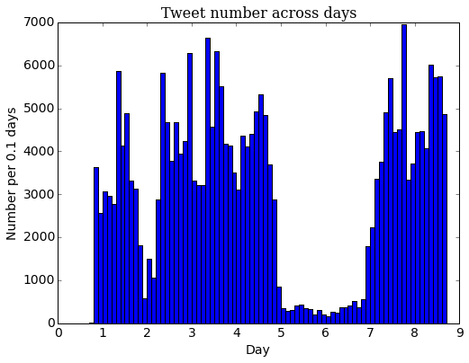

```python
last_dt = math.ceil(dts.max())
bin_size = 0.1
bins = np.arange(0, last_dt, bin_size)

histo = np.histogram(dts, bins=bins)

fig = plt.figure(figsize=(8,6))
plt.bar(histo[1][:-1], histo[0], width=bin_size)
plt.xlabel('Day')
plt.ylabel('Number per {} days'.format(bin_size))
plt.gca().set_title('Tweet number across days')
```

4000 / 0.1 days = 40,000 / day = roughly 28 / minute

Is there a daily pattern?

```python
bin_size = 0.5/24
bins = np.arange(0, 1, bin_size)
bin_midpoints = (bins + bin_size/2)[:-1]
histos = []
histos = [np.histogram(dts[(dts < day) & (dts > (day-1))]-(day-1), bins=bins) for day in range(1, 10)]
```

```python
from matplotlib.ticker import FuncFormatter

def time_fmt(t, pos):
    return '{}:{:}'.format(int(t*24), int((t*24-math.floor(t*24))*60))
time_formatter = FuncFormatter(time_fmt)
```

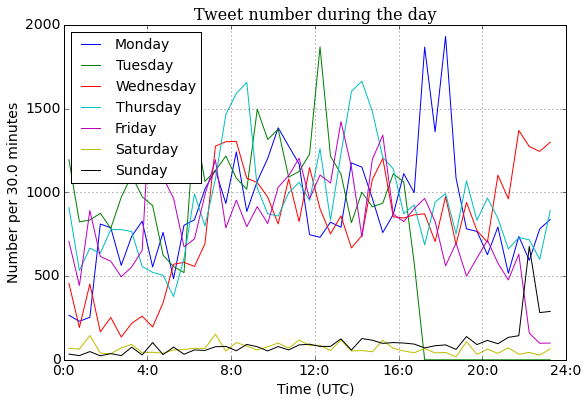

```python
day_names = ['Monday', 'Tuesday', 'Wednesday', 'Thursday', 'Friday', 'Saturday', 'Sunday', 'Monday', 'Tuesday']

plot_data = pd.DataFrame()
plot_data['times'] = bin_midpoints
for i, histo in enumerate(histos):
    plot_data[day_names[i]] = histo[0]

plot_data.plot(x='times', figsize=(9,6))
plt.xlabel('Time (UTC)')
plt.gca().xaxis.set_major_formatter(time_formatter)
plt.gca().set_xticks([0, 1/6, 2/6, 3/6, 4/6, 5/6, 1])
plt.ylabel('Number per {} minutes'.format(bin_size*24*60))
plt.gca().set_title('Tweet number during the day')
```

How about trying to fit a sine curve to this?

```python
import math
fit_data = pd.DataFrame()
for i, histo in enumerate(histos):
    if day_names[i] in ['Saturday', 'Sunday']:
        continue
    tmp = pd.DataFrame()
    tmp['t'] = bin_midpoints
    tmp['y'] = histo[0]
    tmp = tmp[tmp['y'] != 0]
    fit_data = pd.concat([fit_data, tmp])

fit_data['sin(2pit)'] = fit_data['t'].apply(lambda t: math.sin(2*math.pi*t))
fit_data['cos(2pit)'] = fit_data['t'].apply(lambda t: math.cos(2*math.pi*t))

X = fit_data[['sin(2pit)', 'cos(2pit)']]
y = fit_data['y']
```

```python
from sklearn.linear_model import LinearRegression
regr = LinearRegression()
regr.fit(X, y)
print('Coefficients: {}'.format(regr.coef_))
print('Intercept: {}'.format(regr.intercept_))
print('Variance score: {:.2%}'.format(regr.score(X, y)))
```

```
Coefficients: [  -3.38093694 -253.91004159]
Intercept: 847.299339885
Variance score: 28.81%
```

Remember, $\sin(t+\phi) = \sin t \cos \phi + \cos t \sin \phi $

So, can solve $A \cos\phi = c1$ and $A \sin\phi = c2$, giving $A^2 = c1^2 + c2^2$ and $tan\phi = \frac{c2}{c1}$

```python
b = regr.intercept_
c1, c2 = regr.coef_

A = math.sqrt(c1**2 + c2**2)
phi = np.arctan(c2/c1)
print('A={}, phi={}'.format(A, phi))
```

```
A=253.932550011, phi=1.5574816224
```

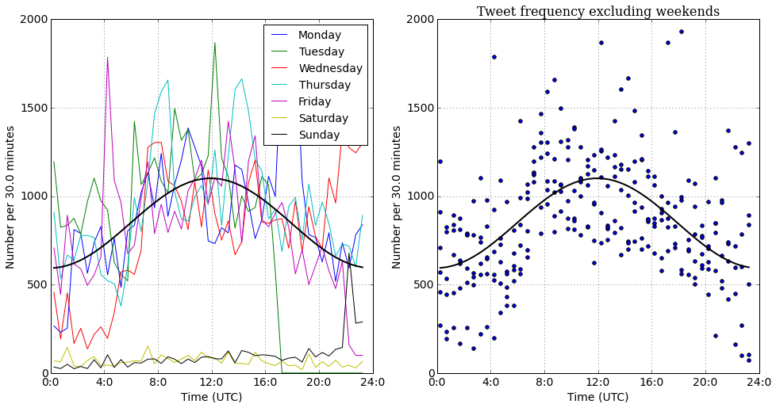

```python
fn = lambda t: b + A * np.sin(2 * math.pi * t - phi)
#fn = lambda t: b + c1 * np.sin(2*math.pi*t) + c2 * np.cos(2*math.pi*t)
fn = np.vectorize(fn)
ys = fn(bin_midpoints)

f, (ax1, ax2) = plt.subplots(1, 2, figsize=(16, 8))
plot_data.plot(x='times', ax=ax1)
ax1.plot(bin_midpoints, ys, color='k', linewidth=2)
ax1.set_xlabel('Time (UTC)')
ax1.xaxis.set_major_formatter(time_formatter)
ax1.set_xticks([0, 1/6, 2/6, 3/6, 4/6, 5/6, 1])
ax1.set_ylabel('Number per {} minutes'.format(bin_size*24*60))

fit_data.plot(kind='scatter', x='t', y='y', ax=ax2)
ax2.plot(bin_midpoints, ys, color='k', linewidth=2)
ax2.set_xlim(0, 1)
ax2.set_ylim(0, 2000)
ax2.set_title('Tweet frequency excluding weekends')
ax2.set_xlabel('Time (UTC)')
ax2.xaxis.set_major_formatter(time_formatter)
ax2.set_xticks([0, 1/6, 2/6, 3/6, 4/6, 5/6, 1])
ax2.set_ylabel('Number per {} minutes'.format(bin_size*24*60))
```

(ok, I cheated and put in -phi in the above, I couldn't see where I'd flipped the sign)

We could take this further, do some cross validation etc (preferably with more days of data), but we'll leave it there for now.

Also, with some cleaning of the above code, you could look at whether tweets for different currencies had peaks at different times of day (eg UsdMxn being in US timezones, UsdJpy more in Japan).

### Sentiment

```python
from textblob import TextBlob

texts = [tweet['text'] for tweet in tweets]
sentiments = [TextBlob(txt).sentiment for txt in texts]
```

```python
d = [[texts[i], sentiments[i][0], sentiments[i][1]] for i, txt in enumerate(texts)]
sents = pd.DataFrame(d, columns=['Text', 'Polarity', 'Subjectivity'])
```

```python
max_colwidth = pd.get_option('max_colwidth')
pd.set_option('max_colwidth', 100)
display(sents.sort('Polarity').head(10))
display(sents.sort('Polarity', ascending=False).head(10))
pd.set_option('max_colwidth', max_colwidth)
```

|  | Text | Polarity | Subjectivity |
| --- | --- | --- | --- |
| 55649 | RT @sacredrefugeFX: #EURUSD $EURUSD is being really really annoying ! | -1.000 | 0.900000 |
| 55602 | #EURUSD $EURUSD is being really really annoying ! | -1.000 | 0.900000 |
| 105458 | I reset USD shorts vs EUR and JPY, SL at 119.50 and 1.1340. USDJPY looks especially ugly | -1.000 | 1.000000 |
| 114522 | @blueskiesatx Percentages say not until it courts the 161.8. For thrills USDJPY flipped algos i... | -1.000 | 1.000000 |
| 59627 | The sideways moves continues for #EURUSD but is the worst yet to come? \n Cue: #oil prices &amp;... | -1.000 | 1.000000 |
| 14486 | UK #Osbrone says: danger of a miscalculation leading to very bad outcome between #Greece &amp; #... | -1.000 | 0.866667 |
| 92138 | can anyone plz explain to me #wtf is going on with #usdjpy ???!?!!! | -1.000 | 1.000000 |
| 31698 | #eurusd about to do something nasty | -1.000 | 1.000000 |
| 32216 | Gold, Crude Oil and USD/JPY all on the watchlist! | -0.875 | 1.000000 |
| 110529 | @andrewunknown as mentioned yesterday, USDMXN USDBRL reversal will be a brutal flood. | -0.875 | 1.000000 |

|  | Text | Polarity | Subjectivity |
| --- | --- | --- | --- |
| 124089 | Bought #EURUSD 1.1396. Best broker http://t.co/Dyym4UgsKe | 1 | 0.30 |
| 45347 | Good morning traders! $EURUSD levels from yesterday still intact. GL! | 1 | 0.60 |
| 40186 | USDJPY chart structure: excellent. http://t.co/PdENTyiQqi | 1 | 1.00 |
| 41050 | Hurry up to get the chance to win the device! Participate in the JustForex promhttp://goo.gl/GF2... | 1 | 0.40 |
| 11773 | Hurry up to get the chance to win the device! Participate in the JustForex promhttp://goo.gl/GF2... | 1 | 0.40 |
| 57436 | #EURUSD trading ranges, looks perfect with the known supports and resistances http://t.co/oiVlUT... | 1 | 1.00 |
| 75135 | USDJPY Reversal of a bull trend SELL best binary expiration 10 mins says Abe Cofnas | 1 | 0.30 |
| 54815 | #Goodmorning #USA and have a GREAT Trading Day! $EURUSD $USDJPY $ES_F #stocks #Forex #Markets #... | 1 | 0.75 |
| 102886 | Perfect selling opportunity for GBPUSD #forex | 1 | 1.00 |
| 103127 | +++ Best Forex Signal : GBP/USD Rally on Optimistic BOE Inflation Report http://t.co/anRVOtZnhv | 1 | 0.30 |

```
Mean = 3.7%
```

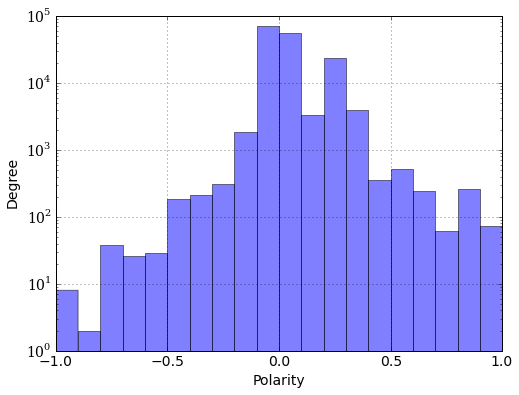

```python
sents[['Polarity']].plot(kind='hist', alpha=0.5, bins=20, figsize=(8, 6))
plt.gca().set_yscale('log')
plt.legend().set_visible(False)
plt.gca().set_xlabel('Polarity')
print('Mean = {:.1%}'.format(sents['Polarity'].mean()))
```

### Tweeters

```python
tweeters = data[['_id', 'user', 'user_followers']].groupby('user').aggregate({'_id':'count', 'user_followers': 'mean'})
```

Who tweets the most?

```python
tweeters.sort('_id', ascending=False)[:20]
```

| user | _id | user_followers |
| --- | --- | --- |
| KhooForex | 3171 | 1133.842636 |
| aheadsupfx | 1824 | 188.192434 |
| tradingextreme1 | 1140 | 1252.919298 |
| jsstriplerindo1 | 1067 | 54.319588 |
| FXmstGBP | 1061 | 877.747408 |
| Steve_Richard_ | 1046 | 88.882409 |
| jenniferreis0 | 1045 | 391.841148 |
| aletheafx12 | 1044 | 59.205939 |
| ArnoldWenz | 1031 | 111.341416 |
| AbdielDeangel12 | 1012 | 40.993083 |
| charlotteacker8 | 1002 | 158.524950 |
| jungmin_fx | 992 | 118.023185 |
| RAdamsFX | 992 | 49.897177 |
| NatalyaFX | 985 | 186.530964 |
| tiffanyfx | 980 | 3047.660204 |
| GouldingMaria | 978 | 34.097137 |
| jacekniemczyk | 971 | 33.193615 |
| HinnTrader | 960 | 92.291667 |
| AhismaSha | 953 | 48.250787 |
| TomaszFXPolska | 948 | 369.496835 |

```python
max_colwidth = pd.get_option('max_colwidth')
pd.set_option('max_colwidth', 100)
display(data[data['user']=='KhooForex'][['text']][:20])
pd.set_option('max_colwidth', max_colwidth)
```

|  | text |
| --- | --- |
| 170 | RT Terry Lucia FX fx_lucia :\nClosed Buy 1.3 Lots EURUSD 1.13323 for +3.5 pips, total for today... |
| 173 | RT FOREX SIGNALS SMS fxpremiere :#和谐 #forex #forexsignal #fxpremiere #eurusd #usdchf Forex Sign... |
| 182 | RT Sergejs Maslobojevs SMaslobojevs :\nBIG Money Is Made NOT By Working Hard But By "Working" S... |
| 548 | RT 25 PIPs Per Day 25PIPsPerDay :\nForex Trading Signal - GBP/USD - http://t.co/mT0hydmEYc; - #... |
| 549 | RT ForexTradingSignals FSignals :\nDaily Analysis - GBP/USD - http://t.co/atl6myMOHR - #forexsi... |
| 940 | RT Alethea Tifft aletheafx12 :\nClosed Sell 1.8 Lots EURUSD 1.13374 for -5.9 pips, total for to... |
| 941 | RT Mary Brewerfx brewerfx_mary :\nClosed Sell 1.5 Lots EURUSD 1.13376 for -4.0 pips, total for ... |
| 942 | RT Alethea Tifft aletheafx12 :\nClosed Sell 1.8 Lots EURUSD 1.13376 for -5.7 pips, total for to... |
| 943 | RT Mary Brewerfx brewerfx_mary :\nClosed Buy 1.5 Lots EURUSD 1.13395 for +4.2 pips, total for t... |
| 944 | RT MT5ForexExpert MT5_ForexExpert :\nClosed Buy 1.9 Lots EURUSD 1.13375 for +3.1 pips, total fo... |
| 945 | RT Alethea Tifft aletheafx12 :\nClosed Buy 1.8 Lots EURUSD 1.13483 for -5.4 pips, total for tod... |
| 946 | RT Mary Brewerfx brewerfx_mary :\nClosed Buy 1.5 Lots EURUSD 1.13416 for +4.0 pips, total for t... |
| 947 | RT Alethea Tifft aletheafx12 :\nClosed Buy 1.8 Lots EURUSD 1.13395 for +4.2 pips, total for tod... |
| 948 | RT Mary Brewerfx brewerfx_mary :\nClosed Buy 1.5 Lots EURUSD 1.13423 for +3.3 pips, total for t... |
| 949 | RT MT5ForexExpert MT5_ForexExpert :\nClosed Buy 1.9 Lots EURUSD 1.13377 for +4.0 pips, total fo... |
| 950 | RT Alethea Tifft aletheafx12 :\nClosed Buy 1.8 Lots EURUSD 1.13423 for +3.3 pips, total for tod... |
| 951 | RT MT5ForexExpert MT5_ForexExpert :\nClosed Buy 1.9 Lots EURUSD 1.13383 for +3.8 pips, total fo... |
| 952 | RT Alethea Tifft aletheafx12 :\nClosed Buy 1.8 Lots EURUSD 1.13416 for +4.0 pips, total for tod... |
| 953 | RT MT5ForexExpert MT5_ForexExpert :\nClosed Buy 1.9 Lots EURUSD 1.13428 for -2.5 pips, total fo... |
| 954 | RT MT5ForexExpert MT5_ForexExpert :\nClosed Sell 1.9 Lots EURUSD 1.13376 for -3.9 pips, total f... |

Hmmm, these people aren't very popular, and their tweets aren't very interesting. Maybe it's better to start with popular tweeters instead?

```python
tweeters.sort('user_followers', ascending=False)[:20]
```

| user | _id | user_followers |
| --- | --- | --- |
| StockTwits | 3 | 407363.666667 |
| zerohedge | 22 | 238154.227273 |
| taromatsumura | 1 | 166004.000000 |
| markets | 2 | 156072.500000 |
| russian_market | 1 | 136316.000000 |
| Iam360WISE | 1 | 124486.000000 |
| ufologhome | 11 | 100949.636364 |
| Bizitalk | 1 | 100348.000000 |
| DCD_AG_ENGLISH | 3 | 99541.333333 |
| forex_us | 5 | 99363.600000 |
| DailyFX | 32 | 97630.750000 |
| go4forexprofits | 1 | 88901.000000 |
| TheStalwart | 2 | 85753.500000 |
| adamwebb_uk | 1 | 82191.000000 |
| forex_bandar | 1 | 79071.000000 |
| Livetradingnews | 2 | 77523.500000 |
| DirectorsTalk | 1 | 73831.000000 |
| eddyquemas | 15 | 73220.466667 |
| worldwide_inves | 3 | 70829.666667 |
| SeekingAlpha | 1 | 69635.000000 |

```python
max_colwidth = pd.get_option('max_colwidth')
pd.set_option('max_colwidth', 100)
display(data[data['user']=='zerohedge'][['text']][:20])
pd.set_option('max_colwidth', max_colwidth)
```

|  | text |
| --- | --- |
| 2123 | ES algos starting to notice the USDJPY intervention |
| 2162 | Will the BOJ fat finger this latest USDJPY ramp? |
| 27674 | USDJPY on European trial balloon |
| 27802 | USDJPY momentum ignited as per Patek Philippe. |
| 30186 | Must. Keep. Buying. USDJPY |
| 30239 | Market breaks: NASDAQ OPTIONS MKT PROBING ISSUES IN SYMBOLS N-Z. This should help the USDJPY ram... |
| 31905 | EURUSD still 30 pips higher on a refuted rumor |
| 32031 | Virtu's EURUSD algo confused by what is more bullish: Greece in or Greece out |
| 32528 | KURODA: NO CRITICISM AT G-20 ON JAPAN'S MONETARY POLICY. Everyone likes when BOJ buys USDJPY |
| 58866 | USDJPY ramp. |
| 58900 | USDJPY swiss watch &gt; 120 |
| 59235 | DE Shaw ES algos still haven't recalibrated from Oil to USDJPY |
| 59621 | The USDJPY ramp will continue until ES notices |
| 61971 | ES finally green. The USDJPY rampage can finally end |
| 71657 | please keep buying EURUSD |
| 72222 | Now we need a denial of the denial so the first leaker can sell his EURUSD |
| 76402 | You can stop buying EURUSD now |
| 102044 | Aaaand those USDJPY stops... are gone |
| 106219 | EURUSD &gt; 1.14 |
| 110639 | USDJPY LOD |

OK, this is looking better. I've at least heard of zerohedge and SeekingAlpha.

```python
cutoff = 10000
print('All tweets = {}'.format(len(data)))
print('Tweets by popular tweeters = {}'.format(len(data[data['user_followers'] > cutoff])))
```

[output not shown]

Maybe not all of these are golden, but it would be a good place to start.

## A recommendation engine

Let's take the top 20 tweeters by followers, and 'like' them. Then we'll take the top 20 tweeters by tweet count, and 'dislike' them.

Then we'll run this through a normal scikit-learn classifier system, and see if there are some other tweets that are predicted to be liked.

```python
like_users = tweeters.reset_index().sort('user_followers', ascending=False)['user'][:20]
dislike_users = tweeters.reset_index().sort('_id', ascending=False)['user'][:20]
all_users = tweeters.reset_index()['user']
unknown_users = all_users[~(all_users.isin(like_users) | all_users.isin(dislike_users))]

liked_tweets = data[data['user'].isin(like_users) & (data['lang'] == 'en')]
liked_tweets['like'] = 1
disliked_tweets = data[data['user'].isin(dislike_users)]
disliked_tweets['like'] = 0

likes_dislikes = pd.concat([liked_tweets, disliked_tweets])
likes_dislikes = likes_dislikes[['text', 'like']]

texts = likes_dislikes['text']
likes = likes_dislikes['like']

unknown_tweets = data[data['user'].isin(unknown_users)]
```

We'll just look at the text for this classifier (should probably also look at language ...)

```python
ngram_max = 1
binary = False
analyzer = 'word'

from sklearn.feature_extraction.text import CountVectorizer

vect = CountVectorizer(ngram_range=(1,ngram_max), binary=False, lowercase=True, analyzer=analyzer)
X = vect.fit_transform(texts)
y = likes

print(X.shape)
```

```
(23284, 4901)
```

For now, just looking at LogisticRegression - we could look at the probabilities of liking under LogisticRegression, and then set a higher barrier than 50%.

```python
from sklearn.linear_model import LogisticRegression
from sklearn.svm import LinearSVC
from sklearn.naive_bayes import GaussianNB

clf = LogisticRegression()
# clf = LinearSVC()
# clf = GaussianNB() # Doesn't work on sparse matrix!

clf.fit(X, y)
```

```
LogisticRegression(C=1.0, class_weight=None, dual=False, fit_intercept=True,
          intercept_scaling=1, penalty='l2', random_state=None, tol=0.0001)
```

```python
unknown_tweets['like'] = clf.predict(vect.transform(unknown_tweets['text']))
unknown_tweets['like'].sum() / unknown_tweets['like'].count()
```

```
0.18528090623839719
```

```python
max_colwidth = pd.get_option('max_colwidth')
pd.set_option('max_colwidth', 85)
display(unknown_tweets[['user','text']][unknown_tweets['like'] == 1][:20])
pd.set_option('max_colwidth', max_colwidth)
```

|  | user | text |
| --- | --- | --- |
| 0 | Daily_Forex | The $EURUSD market will possibly go much lower, and test at least the 1.10 level.... |
| 12 | NWPCapital | $EURUSD (yellow) vs the Eurozone's differential trade surplus over the US trade d... |
| 13 | CapManagment | GBPUSD - Expanding the Range http://t.co/0EP80PHJsX |
| 15 | rrlatypov | ammm...dont like, usdjpy on h4 for keeping chfjpy open. wait till candle closes |
| 24 | noticiasfx | $GBPUSD encuentra resistencia en 1.5200 http://t.co/FbRjVp2idt |
| 66 | anri_mate | Пара EUR/USD торгуется с понижением в районе 1.1307 |
| 69 | Rubw91 | Cerrado 1 largo de $EURUSD a 1.1339USD ganando 270USD IDOP134267 vía http://t.co... |
| 71 | DivisasFX | #FX GBP/USD encuentra resistencia en 1.5200 http://t.co/M4y5u2fHqG [FXstreet] |
| 73 | juankibcn2000 | Cerrado 1 corto de $USDJPY a 118.52USD ganando 110USD IDOP134268 vía http://t.co... |
| 94 | tksuri_05 | おはようございます #fxch #audjpy #usdjpy #gbpjpy ♡ 04:15♡ |
| 100 | tksuri_06 | おはようございます #fxch #audjpy #usdjpy #gbpjpy ♡ 04:15♡ |
| 150 | Daily_Forex | Curious what the week will bring for the $EURGBP, $EURUSD and other major #Forex ... |
| 162 | SPY_FractAlerts | Don't miss a pip. Trade GBPUSD now. http://t.co/whhbkg18My |
| 213 | FX_Markt | Dollarindex behauptet sich stabil von US-Beschäftigung gestützt http://t.co/eGZy9... |
| 266 | Sara20992 | THE BINARY OPTIONS COMPETITION WIN $100,000 http://t.co/QEwKoFFlNt #EURUSD #GBPUS... |
| 322 | Paypal_USD2JPY | 04:20:30 Paypal changed conversion USDJPY rate #Paypal #PaypalUSDJPY |
| 412 | dowbands | CANADA FX DEBT-Canadian dollar rebounds on crude rally $USDJPY http://t.co/ZDJZ84... |
| 456 | FXStreetNews | $USDJPY heading lower to 118.50 http://t.co/M5ZYkalZdk |
| 492 | MW_forextrading | USD/JPY heading lower to 118.50 http://t.co/1iSwt8cBJP |
| 493 | Autotrades1 | USD/JPY heading lower to 118.50: FXStreet (Edinburgh) - The greenback keeps the n... |

OK, there are some reasonable tweets in there (along with some junk).

Some more things to consider:

1. different classifiers
2. different ngrams
3. use of SVD on the ngrams
4. bringing in more info about the tweet (especially the language!)
5. altering the approach slightly: instead of like / dislike, assign a rating (eg 1 to the disliked users, 5 to the liked users and 3 to the nothings), and then filter on tweets that predict above a 4

Better system:

- Filter by keywords to bring up some sample tweets
- Follow some users selected from these results
- Do some ML off the text and language of the resulting tweets
- Update the ML by liking / disliking the resulting tweets

Product concept:

- Manually consruct a set of likes and dislikes for a specific role
- eg currencies, economics, equities ...
- Use these as 'filters' on the whole twitter firehose
- Allow subscription to a specific role, plus further likes / dislikes in the results

## Realtime filter implementation

```python
from IPython.display import Image
```

[figure not shown]

```python
Image(filename='snapshot1.jpg')
```

[figure not shown]

```python
Image(filename='snapshot2.jpg')
```

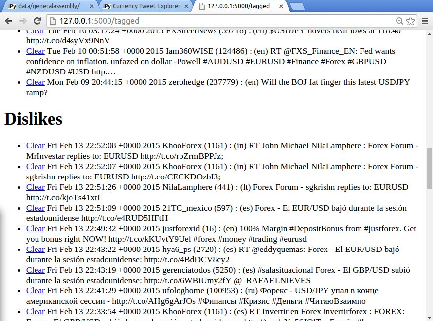

```python
Image(filename='snapshot3.jpg')
```

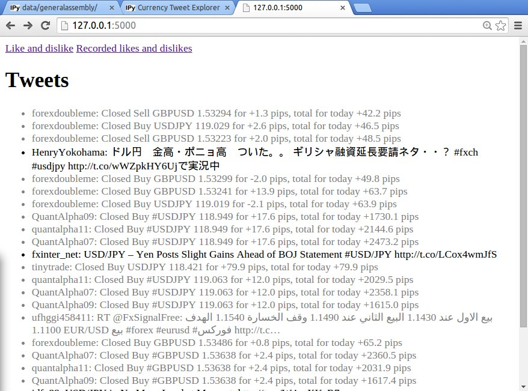

```python
Image(filename='snapshot4.jpg')
```

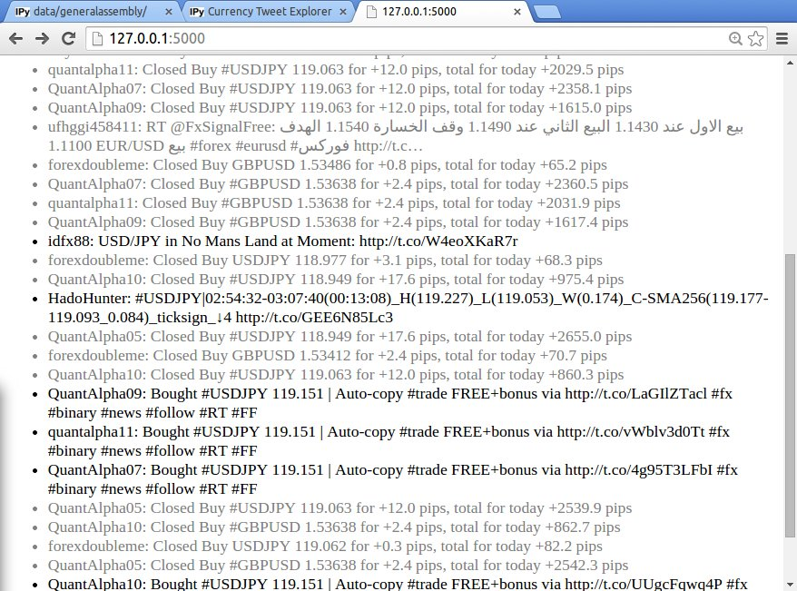

```python
Image(filename='snapshot5.jpg')
```